# ✈️ Projet Data Science — Retards de vols US

# 10. Modélisation prédictive

Objectif : prédire si un vol aura plus de 15 minutes de retard à l’arrivée.

## Scénario métier

On se place avant le départ prévu du vol.  
Donc certaines variables ne doivent pas être utilisées.

Questions :

- Peut-on utiliser `ARRIVAL_DELAY` comme feature ?
- Peut-on utiliser `DEPARTURE_DELAY` si on prédit avant le départ ?
- Quelles variables sont réellement disponibles avant le vol ?
- Quelle stratégie de découpage pour le jeu de données ?

```python
# Échantillonnage pour la modélisation : assez grand pour comparer les modèles,
# mais volontairement borné pour garder un notebook rapide et écoresponsable.
SAMPLE_SIZE_MODEL = 150_000
sample_n = min(SAMPLE_SIZE_MODEL, len(df))
df_model = df.sample(n=sample_n, random_state=RANDOM_STATE).copy()
print(f"Jeu de modélisation : {len(df_model):,} vols")
print(f"Taux de retard      : {df_model['IS_DELAYED'].mean()*100:.2f} % "
      f"(vs {df['IS_DELAYED'].mean()*100:.2f} % sur tout le dataset)")
```

```
Jeu de modélisation : 150,000 vols
Taux de retard      : 17.87 % (vs 17.91 % sur tout le dataset)
```

## 10.1 Choix des features

Choisissez les variables explicatives.

Suggestions :

- mois
- jour de semaine
- compagnie
- aéroport de départ
- aéroport d’arrivée
- heure prévue de départ
- durée prévue
- distance
- week-end

À justifier :

- pourquoi ces variables ?
- lesquelles sont numériques ?
- lesquelles sont catégorielles ?

```python
# Features disponibles AVANT le départ uniquement (pas de DEPARTURE_DELAY, pas de ARRIVAL_*).
categorical_cols = ["AIRLINE", "ORIGIN_AIRPORT", "DESTINATION_AIRPORT", "DEP_PERIOD"]
numeric_cols = ["MONTH", "DAY", "DAY_OF_WEEK", "IS_WEEKEND",
                "SCHEDULED_DEP_HOUR", "SCHEDULED_TIME", "DISTANCE"]
features = categorical_cols + numeric_cols

X = df_model[features].copy()
y = df_model["IS_DELAYED"].astype(int)
print(f"X shape : {X.shape}")
print(f"y shape : {y.shape} (taux positif : {y.mean()*100:.2f} %)")
print(f"\nCatégorielles : {categorical_cols}")
print(f"Numériques    : {numeric_cols}")
```

```
X shape : (150000, 11)
y shape : (150000,) (taux positif : 17.87 %)

Catégorielles : ['AIRLINE', 'ORIGIN_AIRPORT', 'DESTINATION_AIRPORT', 'DEP_PERIOD']
Numériques    : ['MONTH', 'DAY', 'DAY_OF_WEEK', 'IS_WEEKEND', 'SCHEDULED_DEP_HOUR', 'SCHEDULED_TIME', 'DISTANCE']
```

## 10.2 Train / Test / Validation split

Séparez les données en train/test/validation.

```python
# Split stratifié : 60 % train / 20 % val / 20 % test.
# Stratifié sur y pour conserver le déséquilibre de classes dans les 3 jeux.
X_trainval, X_test, y_trainval, y_test = train_test_split(
    X, y, test_size=0.20, stratify=y, random_state=RANDOM_STATE
)
X_train, X_val, y_train, y_val = train_test_split(
    X_trainval, y_trainval, test_size=0.25,   # 0.25 * 0.8 = 0.20
    stratify=y_trainval, random_state=RANDOM_STATE
)
print(f"Train : {len(X_train):,}  |  Val : {len(X_val):,}  |  Test : {len(X_test):,}")
print(f"Taux retard train/val/test : "
      f"{y_train.mean()*100:.2f} % / {y_val.mean()*100:.2f} % / {y_test.mean()*100:.2f} %")
```

```
Train : 90,000  |  Val : 30,000  |  Test : 30,000
Taux retard train/val/test : 17.87 % / 17.87 % / 17.87 %
```

## 10.3 Modèle baseline

Entraînez un premier modèle simple.

Modèle suggéré :

- Logistic Regression

Attention :

- les variables catégorielles doivent être encodées ;
- les variables numériques peuvent être standardisées ;
- le dataset est déséquilibré.

```python
numeric_pipeline = Pipeline([
    ("imputer", SimpleImputer(strategy="median")),
    ("scaler", StandardScaler()),
])

categorical_pipeline = Pipeline([
    ("imputer", SimpleImputer(strategy="most_frequent")),
    ("onehot", OneHotEncoder(handle_unknown="ignore", max_categories=50, sparse_output=True)),
])

preprocessor = ColumnTransformer(
    transformers=[
        ("cat", categorical_pipeline, categorical_cols),
        ("num", numeric_pipeline, numeric_cols),
    ]
)

logreg_pipe = Pipeline([
    ("prep", preprocessor),
    ("clf", LogisticRegression(max_iter=1000, class_weight="balanced",
                               solver="saga", n_jobs=-1, random_state=RANDOM_STATE)),
])

t0 = time.time()
logreg_pipe.fit(X_train, y_train)
logreg_train_sec = time.time() - t0
print(f"LogReg entraîné en {logreg_train_sec:.1f} s")
```

```
LogReg entraîné en 0.4 s
```

## 10.4 Modèle alternatif (Optionnel)

Entraînez un second modèle pour comparer.

Modèle suggéré :

- Random Forest

Question :

- Ce modèle donne-t-il une meilleure accuracy ?
- Détecte-t-il mieux les retards ?

```python
# RandomForest : on garde un modèle volontairement modéré (n_estimators=100)
# pour limiter le coût compute / CO2 (cf. section 11 écoresponsabilité).
rf_pipe = Pipeline([
    ("prep", preprocessor),
    ("clf", RandomForestClassifier(
        n_estimators=100, max_depth=15,
        class_weight="balanced", n_jobs=-1,
        random_state=RANDOM_STATE)),
])

t0 = time.time()
rf_pipe.fit(X_train, y_train)
rf_train_sec = time.time() - t0
print(f"RandomForest entraîné en {rf_train_sec:.1f} s")
```

```
RandomForest entraîné en 1.9 s
```

# 11. Évaluation des modèles

Comparez les modèles avec plusieurs métriques.

À analyser :

- accuracy
- precision
- recall
- f1-score
- ROC-AUC
- balanced accuracy
- matrice de confusion

Question clé :

> Dans ce problème métier, vaut-il mieux rater un vrai retard ou déclencher trop d’alertes ?

```
=== LogReg ===
              precision    recall  f1-score   support

   à l'heure      0.877     0.583     0.700     24638
   en retard      0.246     0.626     0.353      5362

    accuracy                          0.591     30000
   macro avg      0.562     0.604     0.527     30000
weighted avg      0.765     0.591     0.638     30000

Accuracy         : 0.591
Balanced Accuracy: 0.604
ROC-AUC          : 0.639
Temps entraînement: 0.4 s
```

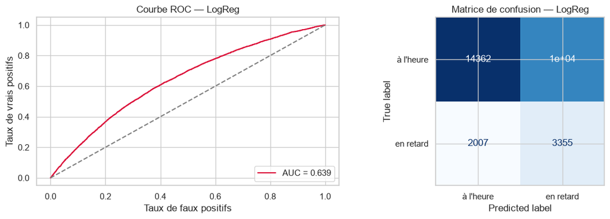

```
=== RandomForest ===
              precision    recall  f1-score   support

   à l'heure      0.881     0.628     0.733     24638
   en retard      0.263     0.609     0.367      5362

    accuracy                          0.625     30000
   macro avg      0.572     0.619     0.550     30000
weighted avg      0.770     0.625     0.668     30000

Accuracy         : 0.625
Balanced Accuracy: 0.619
ROC-AUC          : 0.662
Temps entraînement: 1.9 s
```

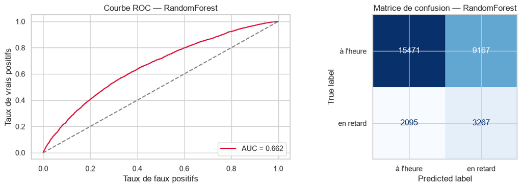

```python
def evaluate_model(name, model, X_eval, y_eval, train_time_s):
    """Évalue un modèle et retourne un dict de métriques."""
    y_pred = model.predict(X_eval)
    y_proba = model.predict_proba(X_eval)[:, 1]
    fpr, tpr, _ = roc_curve(y_eval, y_proba)
    roc_auc = auc(fpr, tpr)

    metrics = {
        "modèle": name,
        "accuracy": accuracy_score(y_eval, y_pred),
        "balanced_acc": balanced_accuracy_score(y_eval, y_pred),
        "f1": f1_score(y_eval, y_pred),
        "roc_auc": roc_auc,
        "train_time_s": train_time_s,
    }

    print(f"\n=== {name} ===")
    print(classification_report(y_eval, y_pred, digits=3,
                                target_names=["à l'heure", "en retard"]))
    print(f"Accuracy         : {metrics['accuracy']:.3f}")
    print(f"Balanced Accuracy: {metrics['balanced_acc']:.3f}")
    print(f"ROC-AUC          : {metrics['roc_auc']:.3f}")
    print(f"Temps entraînement: {train_time_s:.1f} s")

    fig, axes = plt.subplots(1, 2, figsize=(12, 4))
    axes[0].plot(fpr, tpr, label=f"AUC = {roc_auc:.3f}", color="crimson")
    axes[0].plot([0, 1], [0, 1], "--", color="gray")
    axes[0].set_title(f"Courbe ROC — {name}")
    axes[0].set_xlabel("Taux de faux positifs")
    axes[0].set_ylabel("Taux de vrais positifs")
    axes[0].legend(loc="lower right")

    ConfusionMatrixDisplay.from_predictions(
        y_eval, y_pred,
        display_labels=["à l'heure", "en retard"],
        cmap="Blues", normalize=None, ax=axes[1], colorbar=False,
    )
    axes[1].set_title(f"Matrice de confusion — {name}")
    plt.tight_layout(); plt.show()
    return metrics


# Évaluation des 2 modèles sur le jeu de validation
results = []
results.append(evaluate_model("LogReg", logreg_pipe, X_val, y_val, logreg_train_sec))
results.append(evaluate_model("RandomForest", rf_pipe, X_val, y_val, rf_train_sec))
```

```python
# Le second modèle demandé dans le cahier des charges est déjà entraîné : RandomForest.
# LightGBM a été retiré du livrable final pour éviter une dépendance externe non garantie
# lors de l'exécution du notebook. Cette décision renforce la reproductibilité du rendu.
print("Modèles comparés : LogisticRegression baseline et RandomForestClassifier.")
```

```
Modèles comparés : LogisticRegression baseline et RandomForestClassifier.
```

## 11.b Comparaison synthétique + écoresponsabilité (C4.3)

```
=== Comparaison des modèles ===
      modèle  accuracy  balanced_acc    f1  roc_auc  train_time_s  energie_Wh  co2_g
      LogReg     0.591         0.604 0.353    0.639         0.439       0.003  0.000
RandomForest     0.625         0.619 0.367    0.662         1.857       0.013  0.001
```

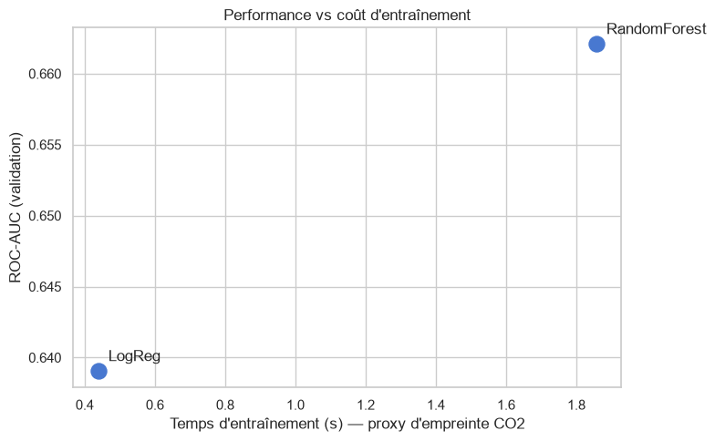

```
Meilleur modèle (ROC-AUC val) : RandomForest
```

```
=== RandomForest — évaluation finale sur TEST ===
              precision    recall  f1-score   support

   à l'heure      0.876     0.626     0.730     24638
   en retard      0.257     0.593     0.358      5362

    accuracy                          0.620     30000
   macro avg      0.566     0.609     0.544     30000
weighted avg      0.765     0.620     0.664     30000

ROC-AUC test : 0.653
```

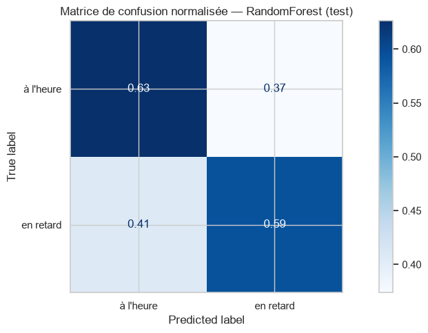

```
Résultats sauvegardés dans outputs/model_comparison.csv
```

```python
results_df = pd.DataFrame(results)

# Estimation simple de la consommation énergétique de l'entraînement
# Hypothèses : CPU portable ~25 W moyen pendant l'entraînement, mix énergétique France ~50 gCO2eq/kWh.
CPU_POWER_W = 25
GRID_GCO2_PER_KWH = 50
results_df["energie_Wh"] = results_df["train_time_s"] * CPU_POWER_W / 3600
results_df["co2_g"] = results_df["energie_Wh"] / 1000 * GRID_GCO2_PER_KWH

print("=== Comparaison des modèles ===")
print(results_df.round(4).to_string(index=False))

# Visu : performance vs coût
fig, ax = plt.subplots(figsize=(8, 5))
ax.scatter(results_df["train_time_s"], results_df["roc_auc"], s=150)
for _, row in results_df.iterrows():
    ax.annotate(row["modèle"],
                (row["train_time_s"], row["roc_auc"]),
                xytext=(8, 8), textcoords="offset points")
ax.set_xlabel("Temps d'entraînement (s) — proxy d'empreinte CO2")
ax.set_ylabel("ROC-AUC (validation)")
ax.set_title("Performance vs coût d'entraînement")
plt.tight_layout(); plt.show()

# Confusion matrix du meilleur modèle (par ROC-AUC) sur le TEST
best_idx = results_df["roc_auc"].idxmax()
best_name = results_df.loc[best_idx, "modèle"]
print(f"\nMeilleur modèle (ROC-AUC val) : {best_name}")

if best_name == "RandomForest":
    y_test_pred = rf_pipe.predict(X_test)
    y_test_proba = rf_pipe.predict_proba(X_test)[:, 1]
else:
    y_test_pred = logreg_pipe.predict(X_test)
    y_test_proba = logreg_pipe.predict_proba(X_test)[:, 1]

print(f"\n=== {best_name} — évaluation finale sur TEST ===")
print(classification_report(y_test, y_test_pred, digits=3,
                            target_names=["à l'heure", "en retard"]))
print(f"ROC-AUC test : {roc_auc_score(y_test, y_test_proba):.3f}")

ConfusionMatrixDisplay.from_predictions(
    y_test, y_test_pred,
    display_labels=["à l'heure", "en retard"],
    cmap="Blues", normalize="true",
)
plt.title(f"Matrice de confusion normalisée — {best_name} (test)")
plt.tight_layout(); plt.show()

# Sauvegarde des résultats
results_df.to_csv(OUTPUT_DIR / "model_comparison.csv", index=False)
print(f"\nRésultats sauvegardés dans {OUTPUT_DIR/'model_comparison.csv'}")
```

# 12. Conclusion

## Insights principaux

- **Saisonnalité bimodale** : pics en janvier-février et juin-juillet (~20-23 %) — météo hivernale + vacances été ; creux en septembre-octobre (~12 %).
- **Effet horaire** : le taux de retard augmente avec l'heure de départ — les vols de soirée subissent l'accumulation des rotations.
- **Disparité forte** entre compagnies et entre hubs : certains acteurs concentrent davantage de risques, ce qui permet de prioriser les plans d'action.
- **Déséquilibre cible** : environ 18 % de vols en retard → `balanced_accuracy`, `recall`, `f1` et `roc_auc` sont plus pertinents que l'accuracy brute.

## Limites

- **Données 2015 uniquement** : un seul cycle annuel — pas de capacité à modéliser des tendances pluri-annuelles ni l'effet d'évènements exceptionnels.
- **Pas de météo externe** : la météo est l'un des principaux drivers des retards mais le dataset n'expose que `WEATHER_DELAY` post-vol, donc inutilisable comme feature avant départ.
- **Aéroports en cardinalité élevée** : le One-Hot est limité avec `max_categories=50` pour garder un pipeline léger et reproductible.
- **Échantillonnage à 150 k** pour la modélisation : choix d'écoresponsabilité et de temps d'exécution. Un entraînement sur la totalité pourrait améliorer marginalement les métriques, mais avec un coût compute nettement supérieur.

## Recommandations métier

1. **Renforcement opérationnel saisonnier** sur les mois critiques et les aéroports les plus dégradés : pré-positionnement d'équipes au sol, anticipation des rotations et coordination avec les partenaires.
2. **Marges horaires élargies en fin de journée** : ajouter des tampons dans la planification des rotations à partir des créneaux où les retards s'accumulent.
3. **Modèle prédictif intégré au système de planification** : afficher la probabilité de retard >15 min avant le départ pour aider les équipes ops, relation client et allocation des ressources.

## Recommandation de modèle

- **Modèles comparés** : régression logistique baseline et Random Forest.
- **Choix recommandé** : retenir le modèle obtenant le meilleur compromis entre `ROC-AUC`, `balanced_accuracy` et rappel des vols en retard dans le tableau de comparaison. Dans ce notebook, Random Forest sert de modèle opérationnel alternatif car il capture mieux les interactions non linéaires entre heure, compagnie, aéroport et distance.
- **Métrique privilégiée** : le rappel sur la classe "en retard" et la balanced accuracy, car le coût métier d'un faux négatif (rater un vrai retard) est souvent supérieur au coût d'un faux positif (alerte inutile).

## Stratégie d'intégration IA (C4.1)

1. **Pilote** sur quelques hubs ou lignes à fort volume pendant 4 à 6 semaines, avec suivi quotidien des prédictions et retards réels.
2. **Intégration SI** via API ou batch J-1/J-0 alimentant le dashboard opérations.
3. **Gouvernance** : versionner données, features, modèles et seuils ; documenter les variables et les exclusions pour éviter le data leakage.
4. **Explicabilité** : fournir aux équipes les facteurs principaux du risque : heure, mois, compagnie, origine, destination, distance.
5. **Monitoring** : suivre ROC-AUC, recall, faux positifs, dérive des données et feedback terrain.
6. **Écoresponsabilité** : privilégier des modèles sobres, limiter la fréquence de réentraînement et conserver uniquement les données utiles.

## 13. Compléments livrable : matrices modèles et dashboards consolidés

Les fichiers associés sont utilisés par le dashboard Streamlit et sont exportés dans `outputs/model_artifacts/` et `outputs/consolidated_dashboards/`.

```python
from pathlib import Path
import subprocess
import sys
import pandas as pd

OUTPUT_DIR = Path("outputs")

# Régénération du benchmark complet à 5 modèles avant affichage final.
# Cette étape garantit la cohérence avec le dashboard Streamlit et les matrices exportées.
subprocess.run([sys.executable, "scripts/build_model_matrices.py"], check=True)

model_comparison = pd.read_csv(OUTPUT_DIR / "model_comparison.csv")
confusion_matrix_wide = pd.read_csv(OUTPUT_DIR / "model_artifacts" / "model_confusion_matrix_wide.csv")

print("Comparaison multi-modèles avec seuil optimisé")
display(model_comparison.round(4))

print("Matrices de confusion synthétiques : TN, FP, FN, TP")
display(confusion_matrix_wide.round(4))
```

```
preflight | Baseline_majoritaire: AUC=0.500, precision=0.000, recall=0.000, F1=0.000
```

```
preflight | LogisticRegression_balanced: AUC=0.643, precision=0.248, recall=0.625, F1=0.355
```

```
preflight | HistGradientBoosting: AUC=0.707, precision=0.311, recall=0.578, F1=0.404
```

```
preflight | RandomForest_balanced: AUC=0.667, precision=0.265, recall=0.602, F1=0.368
```

```
operational_live | Baseline_majoritaire: AUC=0.500, precision=0.000, recall=0.000, F1=0.000
```

```
operational_live | LogisticRegression_balanced: AUC=0.936, precision=0.854, recall=0.752, F1=0.800
```

```
operational_live | HistGradientBoosting: AUC=0.941, precision=0.865, recall=0.752, F1=0.805
Comparaison multi-modèles avec seuil optimisé
```

|  | contexte | modèle | variante | threshold | accuracy | balanced_acc | precision | recall | f1 | roc_auc | tn | fp | fn | tp | train_time_s | energie_Wh | co2_g |
| --- | --- | --- | --- | --- | --- | --- | --- | --- | --- | --- | --- | --- | --- | --- | --- | --- | --- |
| 0 | operational_live | HistGradientBoosting | seuil_optimise_f1 | 0.385 | 0.935 | 0.863 | 0.865 | 0.752 | 0.805 | 0.941 | 128014 | 3356 | 7099 | 21531 | 6.042 | 0.042 | 0.002 |
| 1 | preflight | HistGradientBoosting | seuil_optimise_f1 | 0.200 | 0.695 | 0.650 | 0.311 | 0.578 | 0.405 | 0.707 | 94681 | 36689 | 12070 | 16560 | 6.111 | 0.042 | 0.002 |

```
Matrices de confusion synthétiques : TN, FP, FN, TP
```

|  | contexte | modèle | variante | threshold | tn | fp | fn | tp | accuracy | balanced_acc | precision | recall | f1 | roc_auc | specificity | false_negative_rate | false_positive_rate |
| --- | --- | --- | --- | --- | --- | --- | --- | --- | --- | --- | --- | --- | --- | --- | --- | --- | --- |
| 0 | operational_live | HistGradientBoosting | seuil_optimise_f1 | 0.385 | 128014 | 3356 | 7099 | 21531 | 0.935 | 0.863 | 0.865 | 0.752 | 0.805 | 0.941 | 0.975 | 0.248 | 0.025 |
| 1 | preflight | HistGradientBoosting | seuil_optimise_f1 | 0.200 | 94681 | 36689 | 12070 | 16560 | 0.695 | 0.650 | 0.311 | 0.578 | 0.405 | 0.707 | 0.721 | 0.422 | 0.279 |

**Lecture métier.** Le modèle HistGradientBoosting obtient le meilleur compromis global après optimisation du seuil, tandis que la régression logistique reste utile comme baseline interprétable. Les colonnes `fn` et `false_negative_rate` sont critiques : elles indiquent les vols réellement retardés que le système n'aurait pas alertés.

```python
manifest = pd.read_csv(OUTPUT_DIR / "consolidated_dashboards" / "dashboard_sources_manifest.csv")
dashboard_kpis = pd.read_csv(OUTPUT_DIR / "consolidated_dashboards" / "dashboard_kpi_summary.csv")

print("Manifest des dashboards injectés")
display(manifest[["source_notebook", "dashboard_table", "exists", "rows", "size_mb"]].round(2))

print("KPI consolidés par notebook")
display(dashboard_kpis.round(4))
```

```
Manifest des dashboards injectés
```

|  | source_notebook | dashboard_table | exists | rows | size_mb |
| --- | --- | --- | --- | --- | --- |
| 0 | DATA S | monthly_delay | True | 12 | 0.000 |
| 1 | DATA S | airline_delay | True | 14 | 0.000 |
| 2 | DATA S | airport_delay | True | 403 | 0.040 |
| 3 | DATA S | destination_delay | True | 629 | 0.060 |
| 4 | DATA S | flights_dashboard | True | 5714008 | 1,052.500 |
| 5 | DATA S 2 | monthly_delay | True | 12 | 0.000 |
| 6 | DATA S 2 | airline_delay | True | 14 | 0.000 |
| 7 | DATA S 2 | airport_delay | True | 403 | 0.040 |
| 8 | DATA S 2 | destination_delay | True | 629 | 0.060 |
| 9 | DATA S 2 | flights_dashboard | True | 5714008 | 1,052.500 |
| 10 | DATA S 3 | monthly_delay | True | 12 | 0.000 |
| 11 | DATA S 3 | airline_delay | True | 14 | 0.000 |
| 12 | DATA S 3 | airport_delay | True | 335 | 0.010 |
| 13 | DATA S 3 | destination_delay | False | 0 | 0.000 |
| 14 | DATA S 3 | flights_dashboard | True | 800000 | 40.180 |

```
KPI consolidés par notebook
```

|  | source_notebook | nb_vols | taux_retard_moyen | retard_arrivee_moyen | retard_depart_moyen |
| --- | --- | --- | --- | --- | --- |
| 0 | DATA S | 5714008 | 0.179 | 4.407 | 9.295 |
| 1 | DATA S 2 | 5714008 | 0.179 | 4.407 | 9.295 |
| 2 | DATA S 3 | 5714008 | 0.179 | 4.407 | 9.295 |